# KimbePredsBiomass

# Validation with AIC

```r
AIC(pred.glmmnb2, pred.glmmzi, pred.glmmt)
```

|  | df | AIC |
| --- | --- | --- |
| pred.glmmnb2 | 5 | 644.1610 |
| pred.glmmzi | 6 | 646.1610 |
| pred.glmmt | 6 | 686.5764 |

```
            df  AIC
```

pred.glmmnb2 5 644.1610  
pred.glmmzi 6 646.1610  
pred.glmmt 6 686.5764

NB best fit so will work with this

# Model tweaking

Now going to add the offset

```r
pred.glmmnboff <- update(pred.glmmnb2, ~ . + offset(log(Transect_Fish_Biomass_kg)))
```

# Revalidation with AIC

```r
AIC(pred.glmmnboff, pred.glmmnb2)
```

|  | df | AIC |
| --- | --- | --- |
| pred.glmmnboff | 5 | 519.7927 |
| pred.glmmnb2 | 5 | 644.1610 |

```r
binned_residuals(pred.glmmnboff)
```

|  | xbar | ybar | n | x.lo | x.hi | se | group |
| --- | --- | --- | --- | --- | --- | --- | --- |
| 1 | 0.03694889 | 0.04002423 | 10 | 0.01788185 | 6.134588e-02 | 0.06643132 | yes |
| 2 | 0.14236087 | -0.04804253 | 11 | 0.06652255 | 2.015337e-01 | 0.12413515 | yes |
| 3 | 0.31150664 | 0.02501209 | 11 | 0.22037541 | 3.604180e-01 | 0.30251669 | yes |
| 4 | 0.56123296 | -0.26004148 | 11 | 0.37755124 | 7.787623e-01 | 0.31847458 | yes |
| 5 | 1.13568133 | -0.56676774 | 11 | 0.83046883 | 1.373285e+00 | 0.61270844 | yes |
| 6 | 1.95216662 | -0.52593207 | 11 | 1.39799665 | 2.901752e+00 | 0.45899934 | no |
| 7 | 3.68598577 | 1.61257581 | 11 | 2.90598003 | 4.649104e+00 | 1.57433044 | no |
| 8 | 5.97411985 | -0.73579242 | 11 | 4.71531920 | 7.477056e+00 | 2.88621606 | yes |
| 9 | 11.21153045 | -3.01709954 | 11 | 7.53265590 | 1.439769e+01 | 3.03808339 | yes |
| 10 | 21.67059890 | 2.75921022 | 11 | 16.09899271 | 3.187502e+01 | 8.45800284 | yes |

[output cut: 1 more lines]

- Offset model better fit

# Check summary

```r
#summary(pred.glmmnboff)
```

# Summary output

Family: nbinom2 ( log ) Formula: Transect_biomass_kg ~ Reeftype + (1 | SiteCode) + offset(log(Transect_Fish_Biomass_kg)) Data: merpredsum_kg

```
 AIC      BIC   logLik deviance df.resid
```

519.8 533.7 -254.9 509.8 115

Random effects:

Conditional model: Groups Name Variance Std.Dev. SiteCode (Intercept) 0.07558 0.2749  
Number of obs: 120, groups: SiteCode, 12

Overdispersion parameter for nbinom2 family (): 3.6

Conditional model: Estimate Std. Error z value Pr(>|z|)  
(Intercept) -0.8434 0.1665 -5.065 4.08e-07 ReeftypeOffshore -0.4748 0.2581 -1.839 0.06589 .  
ReeftypeNearshore -1.3489 0.3525 -3.827 0.00013 — Signif. codes: 0 ‘**’ 0.001 ‘**’ 0.01 ‘’ 0.05 ‘.’ 0.1 ‘ ’ 1

# Check emmeans

```r
# To get emmeans contrasts as ratios:
ratios <- emmeans(pred.glmmnboff, pairwise ~ Reeftype, type='response') %>%
  confint()
ratios
```

```
## $emmeans
##  Reeftype  response   SE  df lower.CL upper.CL
##  Pinnacle     24.04 4.00 115    17.28     33.4
##  Offshore     14.95 2.97 115    10.09     22.1
##  Nearshore     6.24 1.94 115     3.36     11.6
##
## Confidence level used: 0.95
## Intervals are back-transformed from the log scale
##
## $contrasts
##  contrast             ratio    SE  df lower.CL upper.CL
##  Pinnacle / Offshore   1.61 0.415 115    0.871     2.97
##  Pinnacle / Nearshore  3.85 1.358 115    1.668     8.90
##  Offshore / Nearshore  2.40 0.881 115    1.001     5.74
##
## Confidence level used: 0.95
## Conf-level adjustment: tukey method for comparing a family of 3 estimates
## Intervals are back-transformed from the log scale
```

```r
# As absolute kg differences (just changing 'type' to 'transform')
results <- emmeans(pred.glmmnboff, pairwise ~ Reeftype, transform='response') %>%
  confint()
results
```

```
## $emmeans
##  Reeftype  response   SE  df lower.CL upper.CL
##  Pinnacle     24.04 4.00 115    16.11     32.0
##  Offshore     14.95 2.97 115     9.08     20.8
##  Nearshore     6.24 1.94 115     2.39     10.1
##
## Confidence level used: 0.95
##
## $contrasts
##  contrast             estimate   SE  df lower.CL upper.CL
##  Pinnacle - Offshore      9.09 4.97 115   -2.706     20.9
##  Pinnacle - Nearshore    17.80 4.44 115    7.257     28.3
##  Offshore - Nearshore     8.71 3.53 115    0.336     17.1
##
## Confidence level used: 0.95
## Conf-level adjustment: tukey method for comparing a family of 3 estimates
```

# emmeans

$emmeans Reeftype response SE df lower.CL upper.CL Pinnacle 24.04 4.00 115 17.28 33.4 Offshore 14.95 2.97 115 10.09 22.1 Nearshore 6.24 1.94 115 3.36 11.6

# contrasts - ratios:

$contrasts contrast ratio SE df lower.CL upper.CL Pinnacle / Offshore 1.61 0.415 115 0.871 2.97 Pinnacle / Nearshore 3.85 1.358 115 1.668 8.90 Offshore / Nearshore 2.40 0.881 115 1.001 5.74

# contrasts - kg

$contrasts contrast estimate SE df lower.CL upper.CL Pinnacle - Offshore 9.09 4.97 115 -2.706 20.9 Pinnacle - Nearshore 17.80 4.44 115 7.257 28.3 Offshore - Nearshore 8.71 3.53 115 0.336 17.1

## Plots

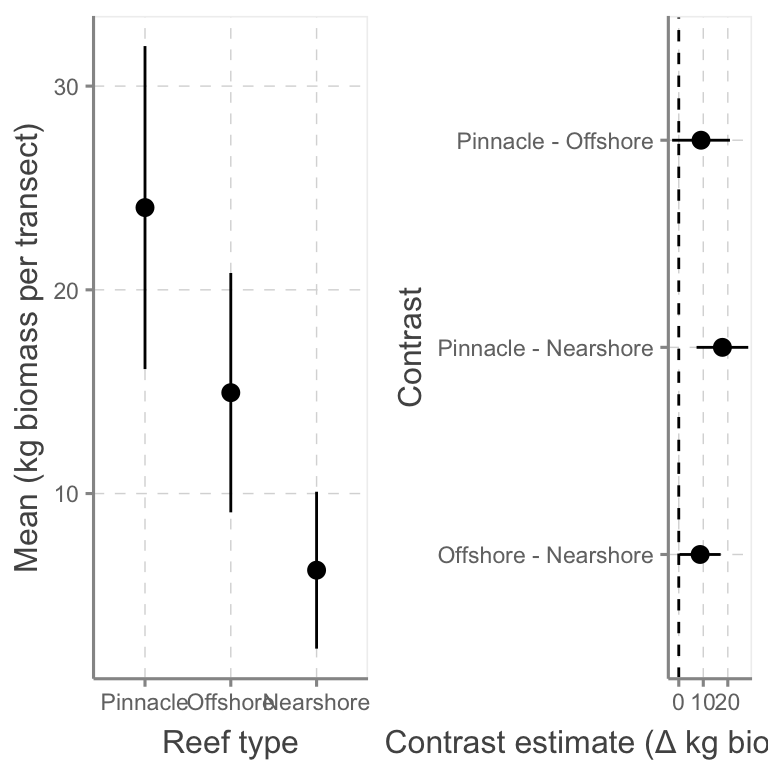

```r
# emmeans figure
plotresults <- ggplot(results$emmeans, aes(y=response,  x=Reeftype)) +
  geom_pointrange(aes(ymin=lower.CL,  ymax=upper.CL))+
  xlab('Reef type')+
  ylab('Mean (kg biomass per transect)')+
  theme_scientific()

# Contrasts figure
plotcontrasts <- ggplot(results$contrasts, aes(y=estimate,  x=contrast)) +
  geom_pointrange(aes(ymin=lower.CL,  ymax=upper.CL))+
  geom_hline(yintercept = 0, linetype='dashed')+
  xlab('Contrast')+
  ylab('Contrast estimate (Δ kg biomass per transect)')+
  coord_flip()+
  theme_scientific()

# Plot together
fig <- grid.arrange(plotresults, plotcontrasts, nrow=1)
```

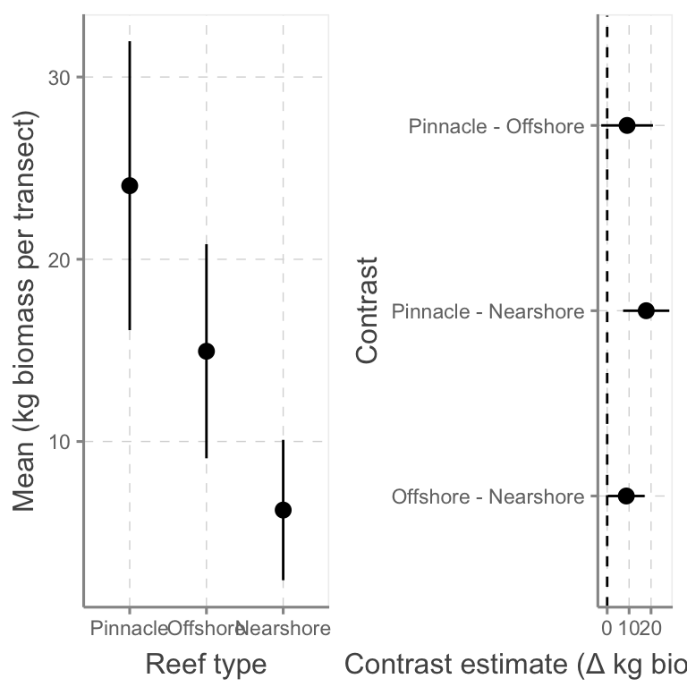

```r
plot(fig)
```

```r
# Save
ggsave(fig, filename= '../../output/rfigures/biomass_fig.png', width=10,  height=3, dpi = 400 )

getwd()
```

```
## [1] "/Users/bjcresswell/OneDrive - James Cook University/Ben PhD/Data & analysis/KimbePreds/code/PredBiomass"
```